# PCIT-CoS-Waitlist RCT Paper 1: DPICS NTA

Nancy Briggs

2024-04-10

### DPICS NTA

#### Descriptives

*Descriptives for Percent Total Time*

| group | time | n | mean | sd | median | min | max |
| --- | --- | --- | --- | --- | --- | --- | --- |
| 1 | 1 | 30 | 4.1508109 | 3.148392 | 3.5923020 | 0.3745318 | 12.672811 |
| 1 | 2 | 22 | 1.1384618 | 1.389791 | 0.5698052 | 0.0000000 | 5.329949 |
| 1 | 3 | 18 | 0.9306564 | 1.085800 | 0.5343094 | 0.0000000 | 4.385965 |
| 2 | 1 | 29 | 4.1856346 | 3.249028 | 3.4391534 | 0.0000000 | 12.716763 |
| 2 | 2 | 12 | 2.8051659 | 2.860190 | 1.9999126 | 0.0000000 | 9.325397 |
| 2 | 3 | 5 | 3.1532309 | 3.408164 | 1.4760148 | 0.7352941 | 8.809524 |
| 3 | 1 | 30 | 4.6964846 | 4.205556 | 3.1224158 | 0.8333333 | 18.820225 |
| 3 | 2 | 26 | 2.3054638 | 2.197483 | 1.8675059 | 0.0000000 | 9.285714 |
| 3 | 3 | 0 | NaN | NA | NA | Inf | -Inf |

[figure not shown]

#### Model & Results

```
## fixed-effect model matrix is rank deficient so dropping 1 column / coefficient
```

This is the ANOVA table for the model. p-values are likelihood ratio tests for adding the new term to the model just before. A p-value <0.05 indicates that adding that term results in better model fit.

|  | Effect | npar | AIC | BIC | logLik | deviance | Chisq | Df | Pr(>Chisq) |
| --- | --- | --- | --- | --- | --- | --- | --- | --- | --- |
| result0 | Intercept | 2 | 1600.692 | 1606.987 | -798.3459 | 1596.692 | NA | NA | NA |
| result1 | Group | 4 | 1601.202 | 1613.792 | -796.6012 | 1593.202 | 3.489524 | 2 | 0.1746866 |
| result2 | Time | 6 | 1340.383 | 1359.268 | -664.1915 | 1328.383 | 264.819295 | 2 | 0.0000000 |
| result3 | Group*Time | 9 | 1273.513 | 1301.840 | -627.7563 | 1255.513 | 72.870412 | 3 | 0.0000000 |

```r
summary(result3)
```

```
## Generalized linear mixed model fit by maximum likelihood (Laplace
##   Approximation) [glmerMod]
##  Family: binomial  ( logit )
## Formula: cbind(nta, verbal - nta) ~ group + time + group * time + (1 |      id)
##    Data: p
##
##      AIC      BIC   logLik deviance df.resid
##   1273.5   1301.8   -627.8   1255.5      163
##
## Scaled residuals:
##     Min      1Q  Median      3Q     Max
## -3.6042 -0.9502 -0.0342  0.4303  4.2112
##
## Random effects:
##  Groups Name        Variance Std.Dev.
##  id     (Intercept) 0.6502   0.8063
## Number of obs: 172, groups:  id, 89
##
## Fixed effects:
##              Estimate Std. Error z value Pr(>|z|)
## (Intercept)   -3.3755     0.1588 -21.260  < 2e-16 ***
## group2        -0.0783     0.2263  -0.346    0.729
## group3         0.1178     0.2230   0.528    0.597
## time2         -1.3744     0.1154 -11.909  < 2e-16 ***
## time3         -1.4937     0.1445 -10.337  < 2e-16 ***
## group2:time2   1.0131     0.1598   6.339 2.31e-10 ***
## group3:time2   0.6078     0.1420   4.281 1.86e-05 ***
## group2:time3   1.5159     0.2187   6.932 4.14e-12 ***
## ---
## Signif. codes:  0 '***' 0.001 '**' 0.01 '*' 0.05 '.' 0.1 ' ' 1
##
## Correlation of Fixed Effects:
##             (Intr) group2 group3 time2  time3  grp2:2 grp3:2
## group2      -0.697
## group3      -0.709  0.497
## time2       -0.124  0.087  0.088
## time3       -0.110  0.077  0.078  0.171
## group2:tim2  0.089 -0.126 -0.064 -0.722 -0.123
## group3:tim2  0.101 -0.071 -0.136 -0.813 -0.139  0.587
## group2:tim3  0.071 -0.105 -0.051 -0.113 -0.661  0.235  0.092
## fit warnings:
## fixed-effect model matrix is rank deficient so dropping 1 column / coefficient
```

#### Estimated Means & Change

Estimated means for each Treatment and Time are presented. In addition, within-group change between time points is presented with 95% CIs.

##### Group mean at each timepoint

Estimated Proportion Number of NTA

| Time | Group | Mean | SE | LowerCL | UpperCL |
| --- | --- | --- | --- | --- | --- |
| 1 | 1 | 0.03307 | 0.00508 | 0.02444 | 0.04461 |
| 2 | 1 | 0.00858 | 0.00157 | 0.00599 | 0.01227 |
| 3 | 1 | 0.00762 | 0.00153 | 0.00514 | 0.01129 |
| 1 | 2 | 0.03066 | 0.00482 | 0.02249 | 0.04166 |
| 2 | 2 | 0.02156 | 0.00389 | 0.01512 | 0.03065 |
| 3 | 2 | 0.03132 | 0.00664 | 0.02063 | 0.04730 |
| 1 | 3 | 0.03705 | 0.00561 | 0.02750 | 0.04975 |
| 2 | 3 | 0.01756 | 0.00286 | 0.01275 | 0.02414 |
| 3 | 3 | NA | NA | NA | NA |

##### Group mean difference at each timepoint

Adjusted p-value from Bonferroni correction.

Between-Group Differences

| Comparison | Time | Ratio | SE | z | p | adj p | Lower CL | Upper CL |
| --- | --- | --- | --- | --- | --- | --- | --- | --- |
| 1 / 2 | 1 | 1.08145 | 0.24469 | 0.34607 | 0.93612 | 1.00000 | 0.63636 | 1.83784 |
| 1 / 3 | 1 | 0.88887 | 0.19821 | -0.52830 | 0.85746 | 1.00000 | 0.52707 | 1.49903 |
| 2 / 3 | 1 | 0.82192 | 0.18521 | -0.87028 | 0.65908 | 1.00000 | 0.48470 | 1.39378 |
| 1 / 2 | 2 | 0.39267 | 0.10209 | -3.59541 | 0.00094 | 0.00097 | 0.21350 | 0.72221 |
| 1 / 3 | 2 | 0.48404 | 0.11983 | -2.93096 | 0.00947 | 0.01014 | 0.27096 | 0.86469 |
| 2 / 3 | 2 | 1.23270 | 0.30490 | 0.84581 | 0.67447 | 1.00000 | 0.69039 | 2.20099 |
| 1 / 2 | 3 | 0.23749 | 0.07071 | -4.82860 | 0.00000 | 0.00000 | 0.11819 | 0.47719 |
| 1 / 3 | 3 | NA | NA | NA | NA | NA | NA | NA |
| 2 / 3 | 3 | NA | NA | NA | NA | NA | NA | NA |

* Effect size here is the odds ratio. A value greater than 1 indicates a relative change in odds of NTA from the reference group.

Here you can see that group1 shows lower odds of MTA at time2 relative to group2 (OR=0.39) and relative to group3 (OR=0.484)

##### Change within each group

Within-Group Change

| Change | Group | OR | SE | z | p | adj p | Lower CL | Upper CL |
| --- | --- | --- | --- | --- | --- | --- | --- | --- |
| 2 / 1 | 1 | 0.253 | 0.029 | -11.909 | 0.000 | 0.000 | 0.193 | 0.332 |
| 3 / 1 | 1 | 0.225 | 0.032 | -10.337 | 0.000 | 0.000 | 0.160 | 0.315 |
| 3 / 2 | 1 | 0.888 | 0.150 | -0.706 | 0.760 | 1.000 | 0.597 | 1.318 |
| 2 / 1 | 2 | 0.697 | 0.077 | -3.269 | 0.003 | 0.003 | 0.538 | 0.903 |
| 3 / 1 | 2 | 1.022 | 0.168 | 0.135 | 0.990 | 1.000 | 0.696 | 1.502 |
| 3 / 2 | 2 | 1.468 | 0.247 | 2.276 | 0.059 | 0.069 | 0.989 | 2.178 |
| 2 / 1 | 3 | 0.465 | 0.038 | -9.275 | 0.000 | 0.000 | 0.383 | 0.564 |
| 3 / 1 | 3 | NA | NA | NA | NA | NA | NA | NA |
| 3 / 2 | 3 | NA | NA | NA | NA | NA | NA | NA |

* Effect size here is the OR of NTA. A value less than 1 indicates lower odds of NTA from the reference timepoint.

Here, you can see that the OR for change in group1 from T1 to T2 is 0.253. This can be interpreted as: the odds of NTA at time 2 was nearly 75% lower than of NTA at time1. The OR for group2 is 0.697, showing an decrease in odds of 30% relative to the odds of NTA at time 1, but it is smaller than the relative decrease for Group1.

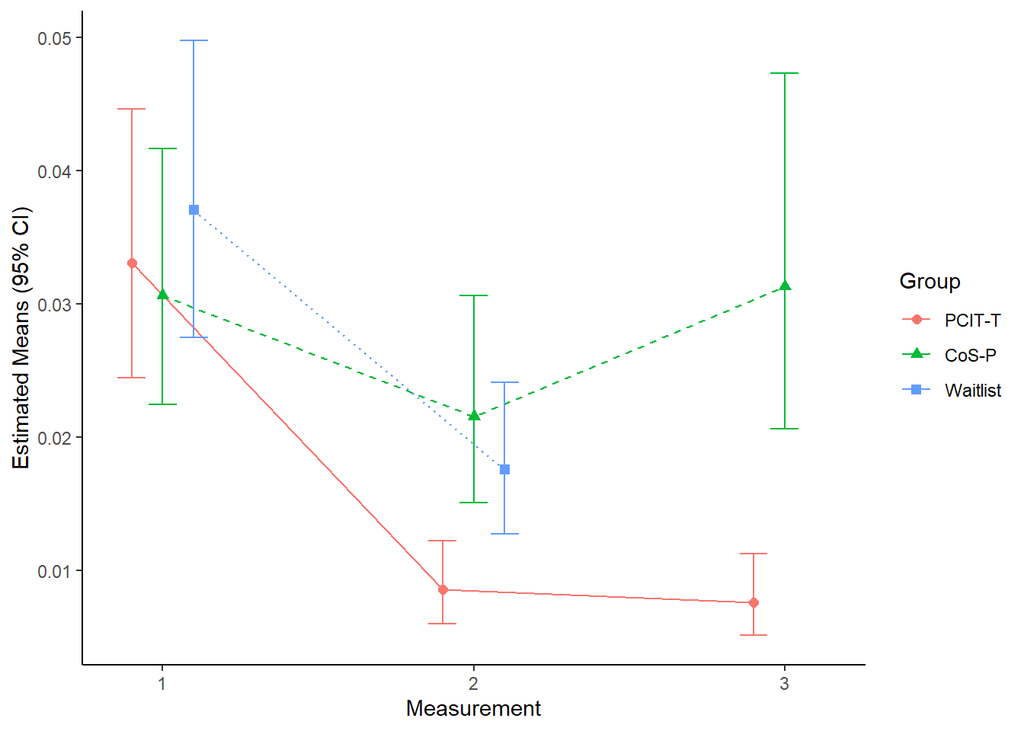

#### Hypothesis 1

We hypothesize that from baseline (‘T1’) to post-treatment/waitlist (‘T2’) there will be a gradient effect, whereby parent-child dyads who receive PCIT-T will show the greatest gains and parent-child dyads who receive no treatment will show the least gains. For the outcome, then, the null hypothesis is:

$H_0: \text {mean change}(\text{PCIT-T}) = \text {mean change}(\text{CoS-P}) = \text {mean change}(\text{Waitlist})$ $H_A: \text {mean change}(\text{PCIT-T}) > \text {mean change}(\text{CoS-P}) > \text {mean change}(\text{Waitlist})$

This is a joint hypothesis test.

```
## group = 1:
##  contrast odds.ratio     SE  df asymp.LCL asymp.UCL
##  2 / 1         0.253 0.0292 Inf     0.193     0.332
##  3 / 1         0.225 0.0324 Inf     0.160     0.315
##  3 / 2         0.888 0.1499 Inf     0.597     1.318
##
## group = 2:
##  contrast odds.ratio     SE  df asymp.LCL asymp.UCL
##  2 / 1         0.697 0.0770 Inf     0.538     0.903
##  3 / 1         1.022 0.1678 Inf     0.696     1.502
##  3 / 2         1.468 0.2473 Inf     0.989     2.178
##
## group = 3:
##  contrast odds.ratio     SE  df asymp.LCL asymp.UCL
##  2 / 1         0.465 0.0384 Inf     0.383     0.564
##  3 / 1        nonEst     NA  NA        NA        NA
##  3 / 2        nonEst     NA  NA        NA        NA
##
## Confidence level used: 0.95
## Conf-level adjustment: tukey method for comparing a family of 3 estimates
## Intervals are back-transformed from the log odds ratio scale
```

Now, to get the p-value associated with the joint hypothesis.

```r
## Specify contrast matrices
# Hyp1 is 1 df test
# could use alternative="less" ir alternative="greater" in glht
hyp1   <- matrix(c(0, 0,0, 0,0, -1,0,0 ),1)
# Hyp2 is 1 df test,
hyp2   <- matrix(c(0, 0,0, 0,1, 0,1,0 ),1)


# hypF is combined 2df test. Yes!
h<-rbind(hyp1,hyp2)
hypF <- as.matrix(h)
GlobalF <- glht(result3, linfct = hypF, test = Ftest())
GlobalF$linfct
```

```
##   (Intercept) group2 group3 time2 time3 group2:time2 group3:time2 group2:time3
## 1           0      0      0     0     0           -1            0            0
## 2           0      0      0     0     1            0            1            0
```

```r
summary(GlobalF, test = Ftest())
```

```
##
##   General Linear Hypotheses
##
## Linear Hypotheses:
##        Estimate
## 1 == 0  -1.0131
## 2 == 0  -0.8859
##
## Global Test:
##       F DF1 DF2    Pr(>F)
## 1 47.37   2 163 6.049e-17
```

```r
#also see this webpage for more on contrasts https://rcompanion.org/rcompanion/h_01.html
```

#### Hypothesis 2

##### Change from T2-T3

There will be a gradient of size of change from T2 to T3 such that the change in the PCIT-T group > the change in the CoS-P group. This isn’t really a gradient; it’s just 1 hypothesis.

First, the change in PCITT and COSP from time 2 to time 3:

```
## group = 1:
##  time    prob      SE  df asymp.LCL asymp.UCL
##  1    0.03307 0.00508 Inf   0.02444    0.0446
##  2    0.00858 0.00157 Inf   0.00599    0.0123
##  3    0.00762 0.00153 Inf   0.00514    0.0113
##
## group = 2:
##  time    prob      SE  df asymp.LCL asymp.UCL
##  1    0.03066 0.00482 Inf   0.02249    0.0417
##  2    0.02156 0.00389 Inf   0.01512    0.0307
##  3    0.03132 0.00664 Inf   0.02063    0.0473
##
## group = 3:
##  time    prob      SE  df asymp.LCL asymp.UCL
##  1    0.03705 0.00561 Inf   0.02750    0.0498
##  2    0.01756 0.00286 Inf   0.01275    0.0241
##  3     nonEst      NA  NA        NA        NA
##
## Confidence level used: 0.95
## Intervals are back-transformed from the logit scale
```

```
## group = 1:
##  contrast odds.ratio     SE  df asymp.LCL asymp.UCL
##  2 / 1         0.253 0.0292 Inf     0.193     0.332
##  3 / 1         0.225 0.0324 Inf     0.160     0.315
##  3 / 2         0.888 0.1499 Inf     0.597     1.318
##
## group = 2:
##  contrast odds.ratio     SE  df asymp.LCL asymp.UCL
##  2 / 1         0.697 0.0770 Inf     0.538     0.903
##  3 / 1         1.022 0.1678 Inf     0.696     1.502
##  3 / 2         1.468 0.2473 Inf     0.989     2.178
##
## group = 3:
##  contrast odds.ratio     SE  df asymp.LCL asymp.UCL
##  2 / 1         0.465 0.0384 Inf     0.383     0.564
##  3 / 1        nonEst     NA  NA        NA        NA
##  3 / 2        nonEst     NA  NA        NA        NA
##
## Confidence level used: 0.95
## Conf-level adjustment: tukey method for comparing a family of 3 estimates
## Intervals are back-transformed from the log odds ratio scale
```

```r
## Specify contrast matrices
# Hyp1 is 1 df test
# could use alternative="less" ir alternative="greater" in glht
hyp2   <- matrix(c(0, 0,0, 0,0, -1,0,1 ),1)
hyp2F <- glht(result3, linfct = hyp2)
summary(hyp2F)
```

```
##
##   Simultaneous Tests for General Linear Hypotheses
##
## Fit: glmer(formula = cbind(nta, verbal - nta) ~ group + time + group *
##     time + (1 | id), data = p, family = binomial)
##
## Linear Hypotheses:
##        Estimate Std. Error z value Pr(>|z|)
## 1 == 0   0.5029     0.2386   2.108    0.035 *
## ---
## Signif. codes:  0 '***' 0.001 '**' 0.01 '*' 0.05 '.' 0.1 ' ' 1
## (Adjusted p values reported -- single-step method)
```

```r
s<-summary(hyp2F, test = Ftest())
#also see this webpage for more on contrasts https://rcompanion.org/rcompanion/h_01.html



## Extract pvaue for evidence / no evidence
evidence = ifelse(s$test$pvalue<0.05, "evidence", "no evidence")
```

Change in G1 from T2 to T3: 0.888

Change in G2 from T2 to T3: 1.468

##### Change from T1-T3

```
##
##   General Linear Hypotheses
##
## Linear Hypotheses:
##        Estimate
## 1 == 0    1.516
##
## Global Test:
##       F DF1 DF2    Pr(>F)
## 1 48.06   1 163 9.183e-11
```

Change in G1 from T1 to T3: 0.225

Change in G2 from T1 to T3: 1.022

p=0. We have evidence that the change from T1 to T3 is different for G1 and G2

#### Residuals

Before interpretation, we should examine model assumptions.

Under H0 (perfect model, no violations of assumptions), we would expect a straight line in the QQplot. Also, scatterplot should show similar spread across the x-axis.

There are no violations of assumptions.

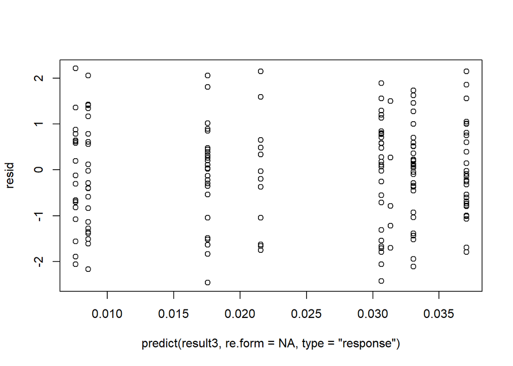

```r
library(DHARMa)

sim= simulateResiduals(result3)
resid = residuals(sim, quantileFunction = qnorm, outlierValues = c(-7,7))
plot(resid~predict(result3, re.form = NA,type="response"))
```

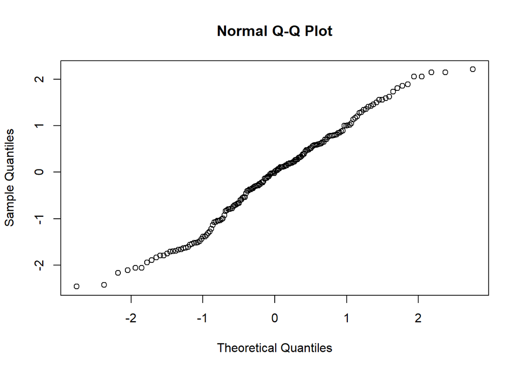

```r
qqnorm(resid)
```

```r
citation("DHARMa")
```

```
##
##
##   Florian Hartig (2022). DHARMa: Residual Diagnostics for Hierarchical
##   (Multi-Level / Mixed) Regression Models. R package version 0.4.5.
##   https://CRAN.R-project.org/package=DHARMa
##
## A BibTeX entry for LaTeX users is
##
##   @Manual{,
##     title = {DHARMa: Residual Diagnostics for Hierarchical (Multi-Level / Mixed)
## Regression Models},
##     author = {Florian Hartig},
##     year = {2022},
##     note = {R package version 0.4.5},
##     url = {https://CRAN.R-project.org/package=DHARMa},
##   }
```

```r
rm(list = ls())
```